# An overview of quantum computing

From the sight of computing science researchers they may think the quantum computing a new computing framework by directly matrix calculations in quantum computers, which will result in an exponential acceleration over classical computing. The related quantum characteristics are quantum superposition and quantum entanglement.

For this stage we don't have a perfect quantum computer with lots of perfect qubits, which means the things we can do today by using quantum computer is very limited. Then the idea of quantum computing simulators are raised. If we consider the quantum operations as matrices and the quantum state a float type array in classical computer, such the process of quantum computing can be simulated. Though the qubits number maybe limited by the storage of classical computer but we can use them to test small scale quantum algorithms. There are many elegant quantum computing simulators we can use without any pay, such as projectq, Cirq of Google and qiskit of IBM.

For quantum computing simulations, we need to claim that it quantum computing simulation is totally different compared to quantum simulation. Quantum simulation mostly refer to simulate some quantum effects such as energy band or evaluting the eigen state of a molecule by using quantum chemistry algorithms. For quantum computing simulations, there are mostly 3 methods used: matrix based, tensor based, Feymann path tensor based. Here another type of simulation method is used, which is based on decision diagram.

```python
# An example of superposition state preparation
import numpy as np
H = np.array([[1, 1], [1, -1]]) / np.sqrt(2)
psi_0 = np.array([1, 0])
psi_t = np.dot(H, psi_0)
print ('The final quantum state vector we got is:\n{}'.format(psi_t))
```

```
The final quantum state vector we got is:
[0.70710678 0.70710678]
```

```python
# An example of entanglement state preparation
H = np.array([[1, 1], [1, -1]]) / np.sqrt(2)
I = np.identity(2)
CX = np.array([[1, 0, 0, 0], [0, 1, 0, 0], [0, 0, 0, 1], [0, 0, 1, 0]])
initial_state = np.array([1, 0])
psi_0 = np.kron(initial_state, initial_state)
psi_1 = np.dot(np.kron(H, I), psi_0)
psi_t = np.dot(CX, psi_1)
print ('The final quantum state vector we got is:\n{}'.format(psi_t))
```

```
The final quantum state vector we got is:
[0.70710678 0.         0.         0.70710678]
```

```
root q0_0 0.70710678
root q0_1 0.70710678
q0_0 1 1
q0_1 1 1
```

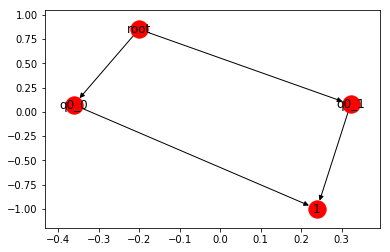

```python
# A weighted decision diagram for state: [0.70710678 0.70710678]
import networkx as nx
graph = nx.DiGraph()
graph.add_nodes_from(['root', 'q0_0', 'q0_1', '1'])
graph.add_weighted_edges_from([('root', 'q0_0', 0.70710678),
                      ('root', 'q0_1', 0.70710678),
                      ('q0_0', '1', 1),
                      ('q0_1', '1', 1)])
nx.draw_networkx(graph)
for (u, v, d) in graph.edges(data=True):
    print (u,v,d['weight'])
```

```
root q0_0 0.70710678
root q0_1 0.70710678
q0_0 q1_0 1
q0_0 0 0
q0_1 q1_2 1
q0_1 0 0
q1_0 1 1
q1_2 1 1
```

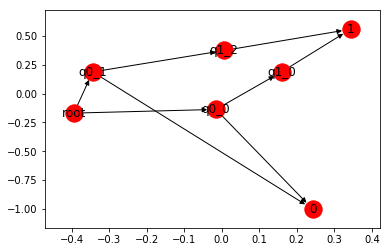

```python
# A weighted decision diagram for state: [0.70710678, 0, 0.70710678, 0]
import networkx as nx
graph = nx.DiGraph()
graph.add_nodes_from(['root', 'q0_0', 'q0_1', 'q1_0', 'q1_2', '0', '1'])
graph.add_weighted_edges_from([('root', 'q0_0', 0.70710678),
                               ('root', 'q0_1', 0.70710678),
                               ('q0_0', 'q1_0', 1),
                               ('q0_0', '0', 0),
                               ('q0_1', 'q1_2', 1),
                               ('q0_1', '0', 0),
                               ('q1_0', '1', 1),
                               ('q1_2', '1', 1)])
nx.draw_networkx(graph)
for (u, v, d) in graph.edges(data=True):
    print (u,v,d['weight'])
```

# There are some examples and simulation results

## How to simulate a state vector?

The quantum state is:$\psi=[0,0,\frac{1}{2},0,\frac{1}{2},0,-\frac{1}{\sqrt{2}},0]$

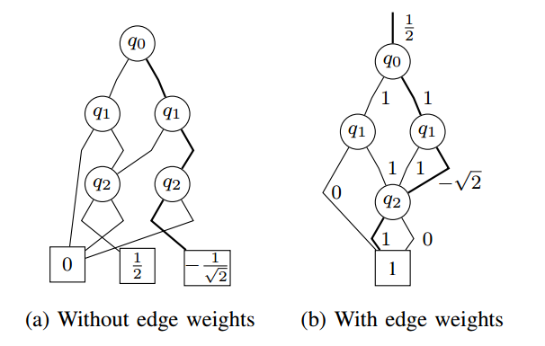

## How to represent a matrice?

The correspond quantum operation are: $H, I, H\otimes I$

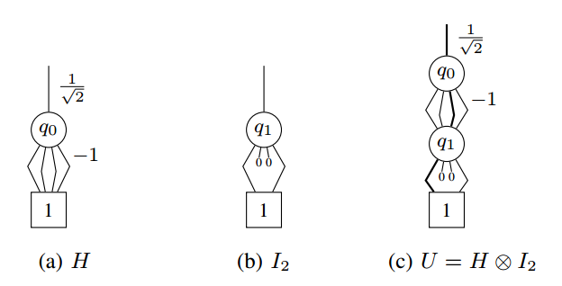

## How to represent matrice dot vertor?

For example we consider: $U\dot \psi$

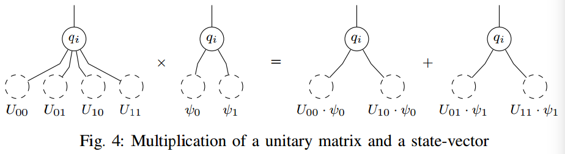

## How to represent a vector plus?

If we got quantum states: $\psi and \phi$

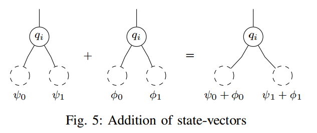

## What if we want to measure or get single amplitude?

Flow the correspond path from the graph.

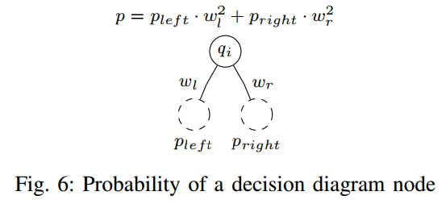

Sometimes we need to normalize the graph amplitudes first.

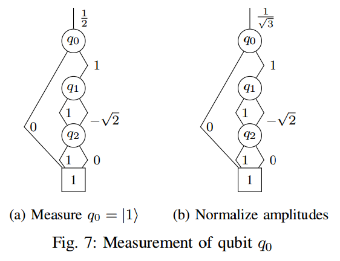

## How is the efficiency of this simulation method?

There are some data from paper "Advanced Simulation of Quantum Computations" by Alwin Zulehner and Robert Wille.

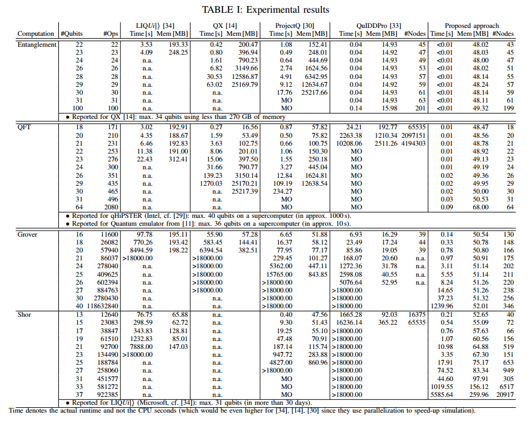